# International Cherry Blossom Prediction Competition

- Show All Code
- Hide All Code
- View Source

EDA 2 and Feature Engineering

Author

Edimer David Jaramillo

Published

February 28, 2024

# Document description

- En este documento el análisis exploratorio de datos está orientado a variables que cambian a través del tiempo. En el documento **05-EDA1.qmd** varios de los resultados hacen uso de la variable respuesta `bloom_doy` resumida con la mediana, en este documento el objetivo es explorar la variación temporal de la variable respuesta y la asociación con variables climáticas (`df_weather`) y fotoperíodo (`df_photoperiod`).

# Libraries and setup

```r
# Libraries
library(tidyverse)
library(arrow)
library(glue)
library(reactable)
library(latex2exp)
library(splines)
library(forecast)

# Colors
colors_custom <-
  c("#014e25",
    "#800080",
    "#ffa500",
    "#008080",
    "#ff6347",
    "#0000cd")

# Theme ggplot2
theme_set(theme_bw() + theme(legend.position = "top"))

# Functions

## These functions are not required in this document
functions_exclude <-
  c(
    "../source/r/module-EDA",
    "../source/r/extractPhotoperiod.R",
    "../source/r/getWeatherPOWER.R"
  )

dir_functions <-
  fs::dir_ls("../source/r/")

c(dir_functions[!dir_functions %in% functions_exclude],
  fs::dir_ls("../source/r/module-EDA/")) |>
  walk(.f = source)

# Inputs
countries <- c("Japan", "Switzerland", "South Korea", "USA-WDC")
```

# Data

- En total hay 490 coordenadas diferentes.
- **`df_full`:** datos completos con ubicaciones (location y country), coordenadas y variable respuesta. Selecciono sólo las variables de interés para este análisis.
  - **Total de filas:** 17966
  - **Total de columnas:** 8
- **`df_weather`:** datos climáticos para cada coordenada
  - **Total de filas:** 7738651
  - **Total de columnas:** 17
  - **Rango de fechas:** 1981-01-01 hasta 2024-02-25
- **df_photoperiod`:** datos de fotoperíodo para cada coordenada
  - **Total de filas:** 9456891
  - **Total de columnas:** 3
  - **Rango de fechas:** 0811-04-02 hasta 2023-12-30
- De la información suministrada por *NPN* (`df_npn`) tomo el `Site_ID == 32789` y la `Species_ID == 228` para identificar los registros del sitio de interés en Nueva York.

```r
# Data with coordinates and response variable
df_full <- read_parquet("../external-data/df_full.parquet") |>
  select(location, country, lat, long, year, bloom_date, bloom_doy) |>
  distinct_all() |>
  mutate(
    location = if_else(
      location == "Switzerland/Z\xfcrich-Albisg\xfcetli",
      true = "Switzerland/Zürich-Albisgüetli",
      false = location
    ),
    location = if_else(
      location == "Switzerland/M\xf6hlin",
      true = "Switzerland/Möhlin",
      false = location
    ),
    location = if_else(
      location == "Switzerland/W\xe4denswil",
      true = "Switzerland/Wädenswil",
      false = location
    ),
    location = if_else(
      location == "Switzerland/Z\xfcrich-MeteoSchweiz",
      true = "Switzerland/Zürich-MeteoSchweiz",
      false = location
    ),
    location = if_else(
      location == "Switzerland/Z\xfcrich-Witikon",
      true = "Switzerland/Zürich-Witikon",
      false = location
    ),
    location = if_else(
      location == "Switzerland/Gr\xfcsch",
      true = "Switzerland/Grüsch",
      false = location
    ),
    location = if_else(
      location == "Switzerland/N\xe4fels",
      true = "Switzerland/Näfels",
      false = location
    ),
    location = if_else(
      location == "Switzerland/Sch\xf6nenwerd",
      true = "Switzerland/Schönenwerd",
      false = location
    ),
    location = if_else(
      location == "Switzerland/D\xf6ttingen",
      true = "Switzerland/Döttingen",
      false = location
    ),
    location = if_else(
      location == "Switzerland/H\xf6fen",
      true = "Switzerland/Höfen",
      false = location
    ),
    location = if_else(
      location == "Switzerland/Le S\xe9pey",
      true = "Switzerland/Le Sépey",
      false = location
    ),
    location = if_else(
      location == "Switzerland/La Br\xe9vine",
      true = "Switzerland/La Brévine",
      false = location
    ),
    location = if_else(
      location == "Switzerland/Alchenfl\xfch",
      true = "Switzerland/Alchenflüh",
      false = location
    ),
    location = if_else(
      location == "Switzerland/Neuch\xe2tel",
      true = "Switzerland/Neuchâtel",
      false = location
    )
  )

# Climate data
df_weather <- read_parquet("../external-data/df_weather.parquet")

# Photoperiod data
df_photoperiod <- read_parquet("../external-data/df_photoperiod.parquet")

# Data NPN
df_npn <- read_parquet("../external-data/df_npn_usa.parquet")

# Coordinates New York
coords_ny <-
  df_npn |>
  filter(Site_ID == 32789) |>
  filter(Species_ID == 228) |>
  distinct(lat, long)
```

# Generalities

- Obtengo una tabla que muestra el rango de fechas de las cuales se tiene registro por cada localización (coordenada), también se agrega el número (`n`) de años de los cuales se tiene registro de floración.
- El registro con fecha mínima de floración es el 01 de abril del año 812.
- Algunas ubicaciones no cuentan con información actualizada. La coordenada *Lat: 46.52733 - Long: 8.932936* tiene 10 registros desde el año 1978 hasta 1987, siendo la coordenada con el registro “más desactualizado”.

```r
df_full |>
  group_by(location, lat, long) |>
  reframe(min_date_doy = min(bloom_date, na.rm = TRUE),
          max_date_doy = max(bloom_date, na.rm = TRUE),
          n = n()) |>
  arrange(min_date_doy) |>
  mutate(across(where(is.numeric), ~ round(.x, digits = 4))) |>
  customReactTable()
```

| location | lat | long | min_date_doy | max_date_doy | n |
| --- | --- | --- | --- | --- | --- |
| kyoto | 35.012 | 135.6761 | 0812-04-01 | 2023-03-25 | 835 |
| liestal | 47.4814 | 7.7305 | 1894-04-16 | 2023-03-29 | 130 |
| washingtondc | 38.8853 | -77.0386 | 1921-03-20 | 2023-03-23 | 103 |
| Switzerland/Zofingen | 47.2918 | 7.941 | 1951-04-15 | 1999-04-24 | 44 |
| Switzerland/Fiesch | 46.4003 | 8.1278 | 1951-04-25 | 2023-04-28 | 63 |
| Switzerland/Posieux | 46.7617 | 7.0983 | 1951-04-26 | 2023-04-14 | 53 |
| Switzerland/Schiers | 46.965 | 9.6858 | 1951-04-26 | 2023-04-23 | 51 |
| Switzerland/Orvin | 47.1578 | 7.2145 | 1951-04-27 | 2023-04-27 | 64 |
| Switzerland/Seewis Dorf | 46.9654 | 9.6321 | 1951-04-27 | 2023-04-23 | 55 |
| Switzerland/Enges | 47.0564 | 7.0122 | 1951-05-05 | 2023-04-22 | 68 |

[output cut: 480 more lines]

# Distribution of days between flowering

- Para calcular la diferencia (en días) entre la floración $t_i$ con $t_{i-1}$ tengo en cuenta coordenadas que cumplan con las siguientes características:
  - Mínimo 2 registros $(n > 1)$
  - Diferencia entre años igual a 1, es decir, sólo conservo coordenadas cuyas floraciones han sido reportadas con una frecuencia anual, no importa si fue hace 20 años, lo importante es que se cuente con información año a año.
- Si llamamos $\gamma$ a la fecha de la floración (`bloom_date`) que tiene mediciones en un año $t$, con $t = 1, 2, ..., k$, donde $k$ es el número de registros que cumplen con las dos restricciones descritas previamente, la distribución que se muestra en los siguientes gráficos es la diferencia de $\gamma_t$ con $\gamma_{t-1}$, es decir, el [operador rezago con $p = 1$](https://en.wikipedia.org/wiki/Lag_operator) sobre la diferencia en días entre floraciones. Es importante mencionar que el usuario podrá elegir el valor del rezago para generar $(\gamma_{t-p})$, en cuyo caso para la primera condición $n$ se expresa como $n = p + 1$; la segunda condición se mantiene igual independientemente del valor que tome $p$.

**\(p = 1\ year\)**

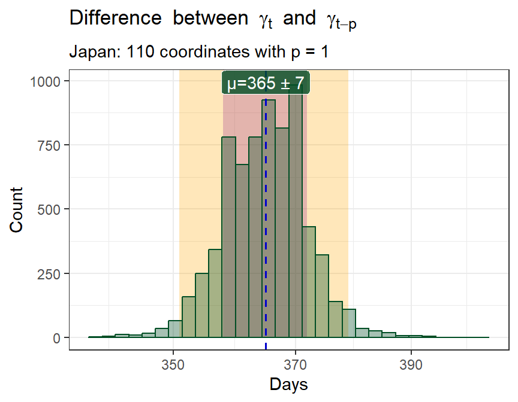

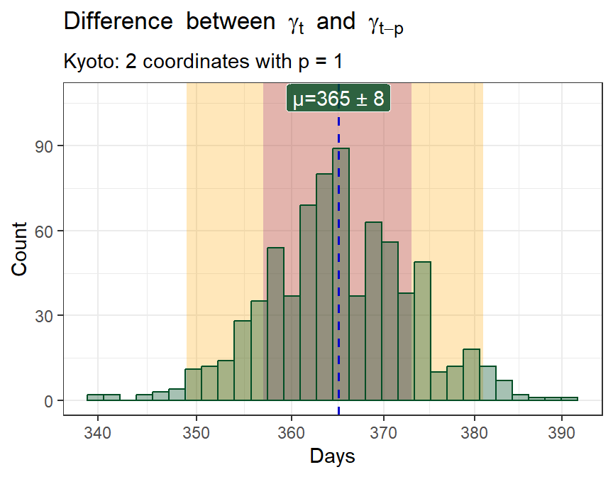

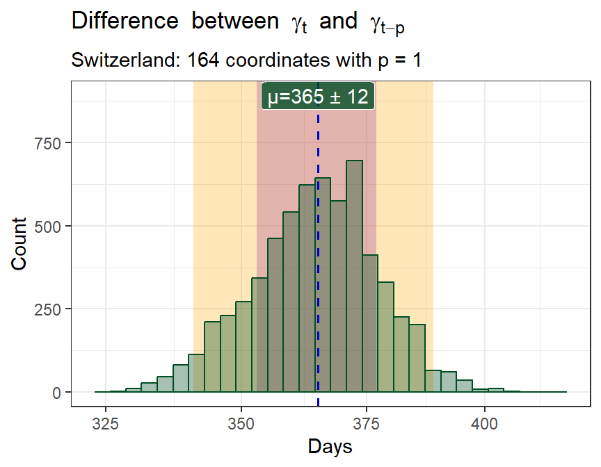

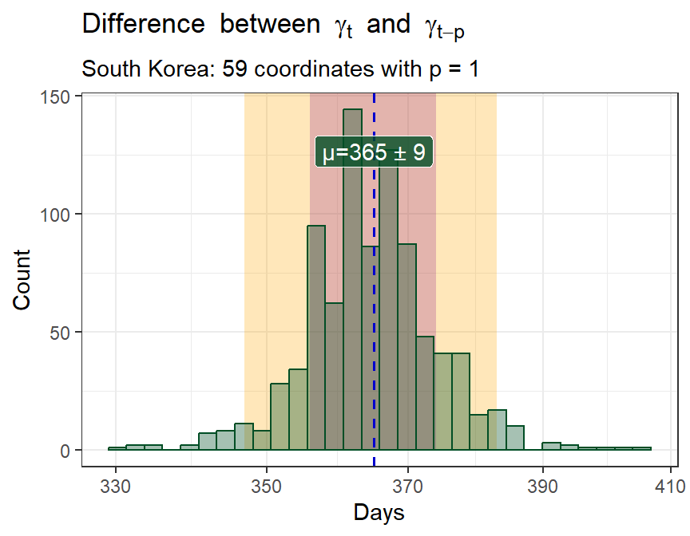

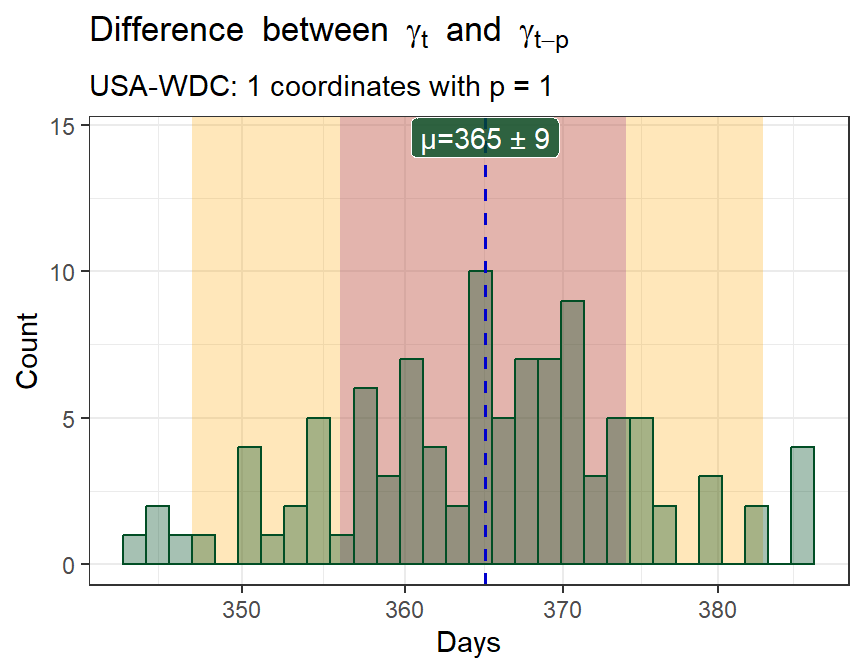

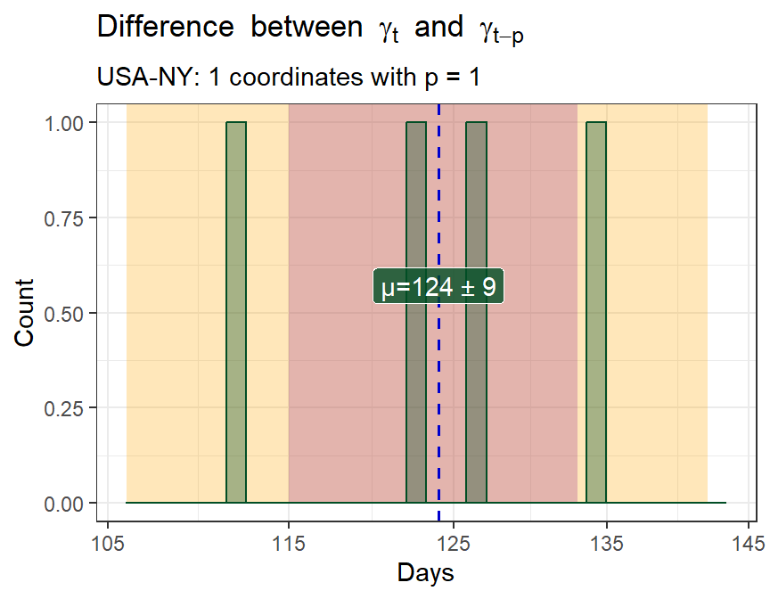

```r
n_lag_operator <- 1

res_japan <-
  lagBloomDate(
    data = df_full,
    n_lag = n_lag_operator,
    country_sel = countries[1],
    pal_colors = colors_custom
  )

res_kyoto <-
  lagBloomDate(
    data = df_full |> filter(str_detect(location, "kyoto|Kyoto|KYOTO")),
    n_lag = n_lag_operator,
    country_sel = countries[1],
    pal_colors = colors_custom
  )

res_switzerland <-
  lagBloomDate(
    data = df_full,
    n_lag = n_lag_operator,
    country_sel = countries[2],
    pal_colors = colors_custom
  )

res_southk <-
  lagBloomDate(
    data = df_full,
    n_lag = n_lag_operator,
    country_sel = countries[3],
    pal_colors = colors_custom
  )

res_usa_wdc <-
  lagBloomDate(
    data = df_full,
    n_lag = n_lag_operator,
    country_sel = countries[4],
    pal_colors = colors_custom
  )

res_usa_ny <-
  lagBloomDate(
    data = df_full |>
      filter(lat %in% coords_ny$lat & long %in% coords_ny$long),
    n_lag = n_lag_operator,
    country_sel = NULL,
    pal_colors = colors_custom
  )

res_japan$plot_diff
res_kyoto$plot_diff +
  labs(subtitle = glue("Kyoto: 2 coordinates with p = {n_lag_operator}"))
res_switzerland$plot_diff
res_southk$plot_diff
res_usa_wdc$plot_diff
res_usa_ny$plot_diff
```

**\(p = 5\ years\)**

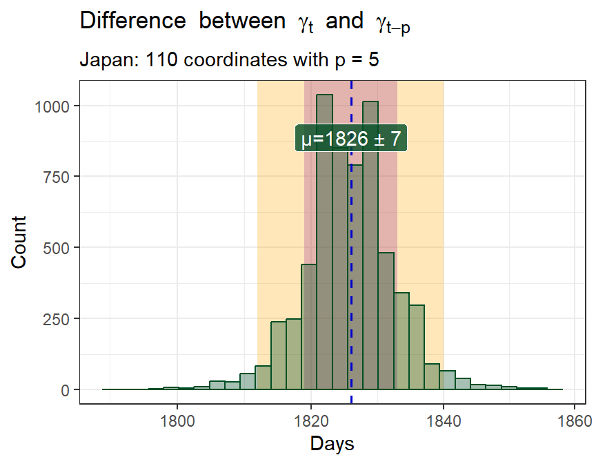

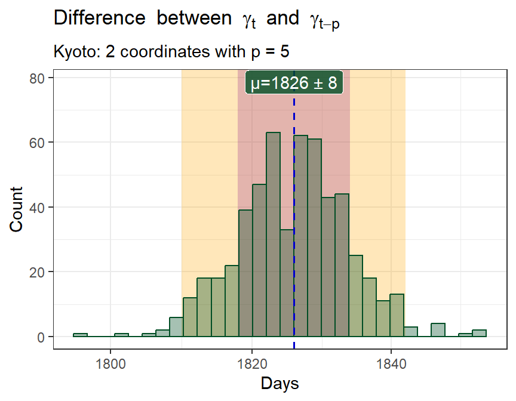

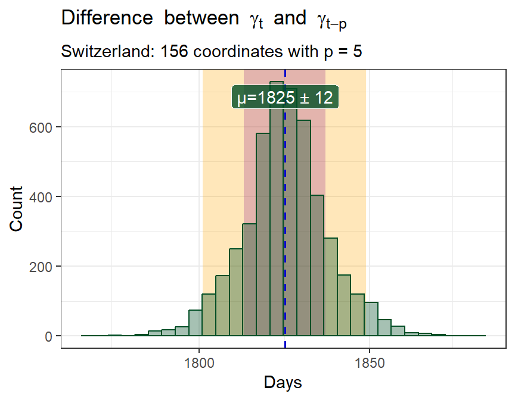

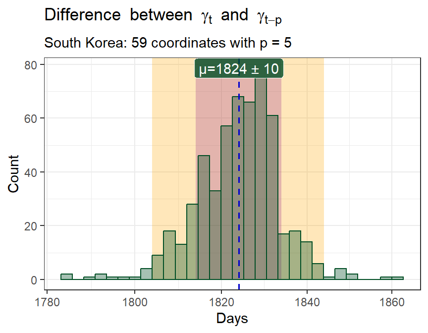

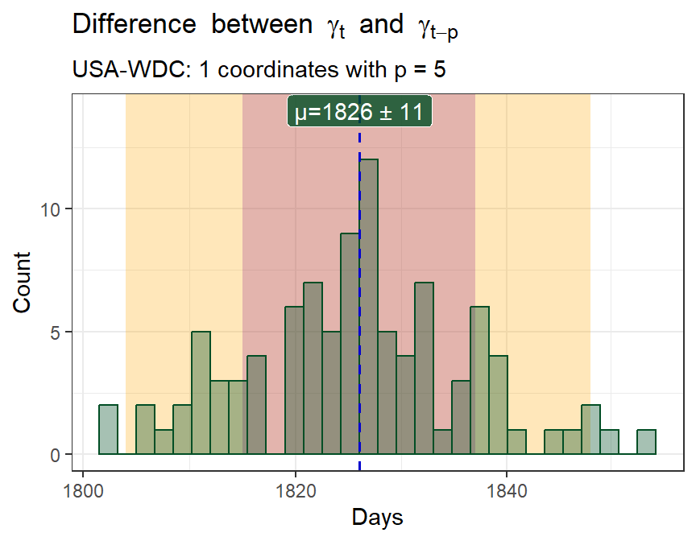

```r
n_lag_operator <- 5

res_japan <-
  lagBloomDate(
    data = df_full,
    n_lag = n_lag_operator,
    country_sel = countries[1],
    pal_colors = colors_custom
  )

res_kyoto <-
  lagBloomDate(
    data = df_full |> filter(str_detect(location, "kyoto|Kyoto|KYOTO")),
    n_lag = n_lag_operator,
    country_sel = countries[1],
    pal_colors = colors_custom
  )

res_switzerland <-
  lagBloomDate(
    data = df_full,
    n_lag = n_lag_operator,
    country_sel = countries[2],
    pal_colors = colors_custom
  )

res_southk <-
  lagBloomDate(
    data = df_full,
    n_lag = n_lag_operator,
    country_sel = countries[3],
    pal_colors = colors_custom
  )

res_usa_wdc <-
  lagBloomDate(
    data = df_full,
    n_lag = n_lag_operator,
    country_sel = countries[4],
    pal_colors = colors_custom
  )

res_japan$plot_diff
res_kyoto$plot_diff +
  labs(subtitle = glue("Kyoto: 2 coordinates with p = {n_lag_operator}"))
res_switzerland$plot_diff
res_southk$plot_diff
res_usa_wdc$plot_diff
```

# DOY lags

- En los siguientes gráficos se relaciona la variable respuesta en el año $t$ con $t-i$. A diferencia de los gráficos anteriores en estos utilizo la variable `bloom_doy` y evalúo una década, es decir, $i = 1, 2, ..., 10$.

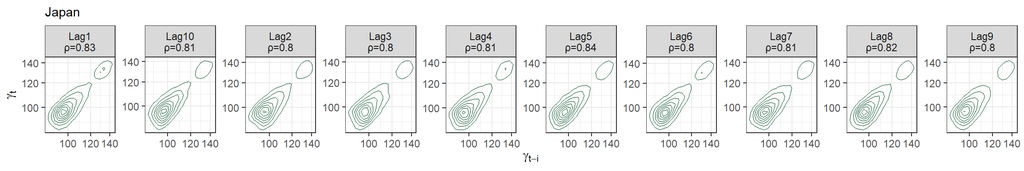

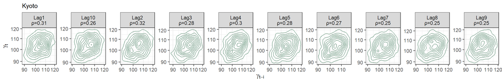

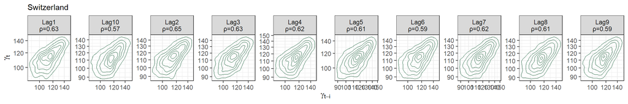

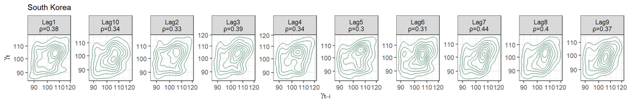

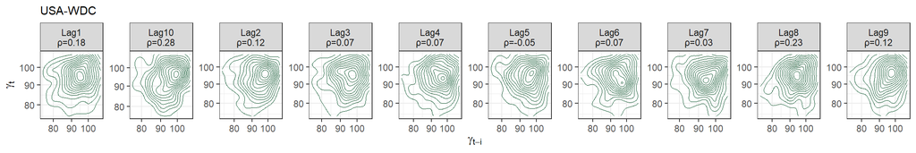

```r
# Japan
lagsDOY(data = df_full,
        country_sel = countries[1],
        pal_colors = colors_custom)$plot_lags
# Tokyo
lagsDOY(data = df_full |> filter(str_detect(location, "kyoto|Kyoto|KYOTO")),
        country_sel = countries[1],
        pal_colors = colors_custom)$plot_lags +
  labs(subtitle = "Kyoto")
# Switzerland
lagsDOY(data = df_full,
        country_sel = countries[2],
        pal_colors = colors_custom)$plot_lags
# South Korea
lagsDOY(data = df_full,
        country_sel = countries[3],
        pal_colors = colors_custom)$plot_lags
# USA-WDC
lagsDOY(data = df_full,
        country_sel = countries[4],
        pal_colors = colors_custom)$plot_lags
```

# Autocorrelation function (ACF)

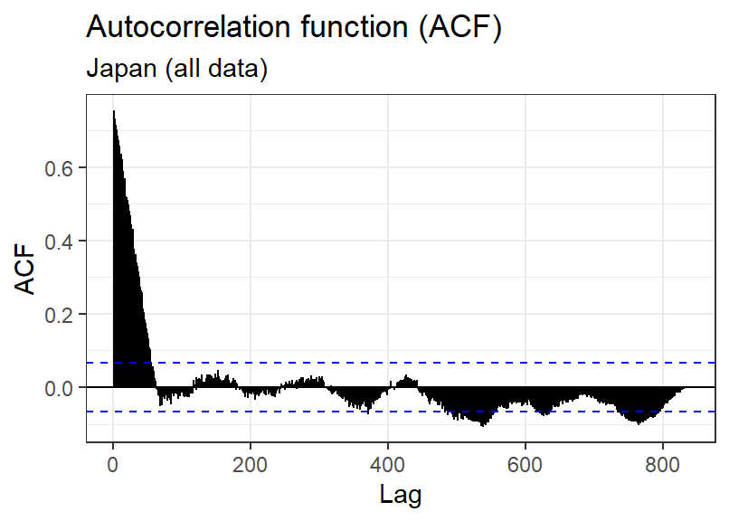

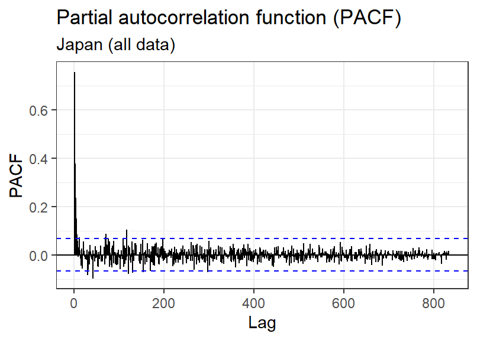

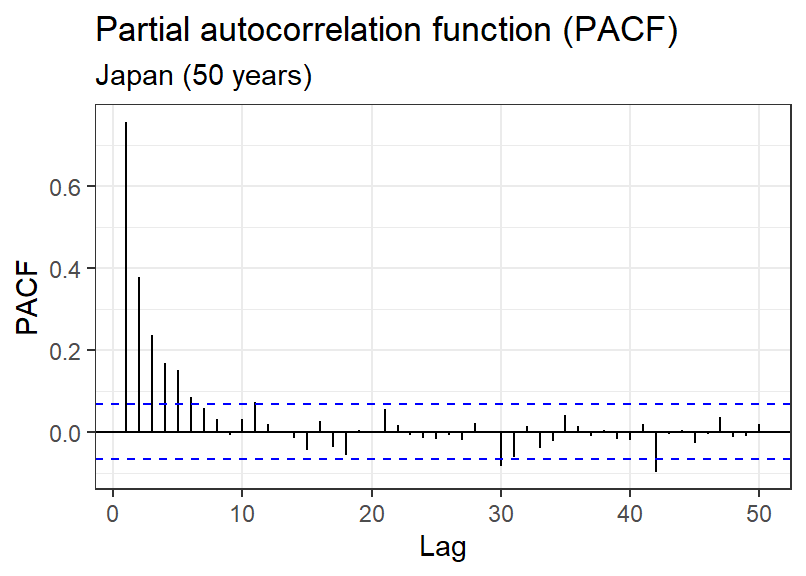

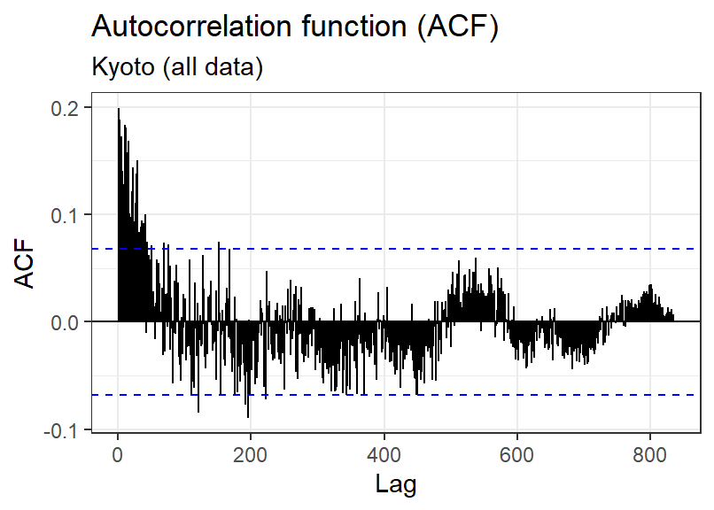

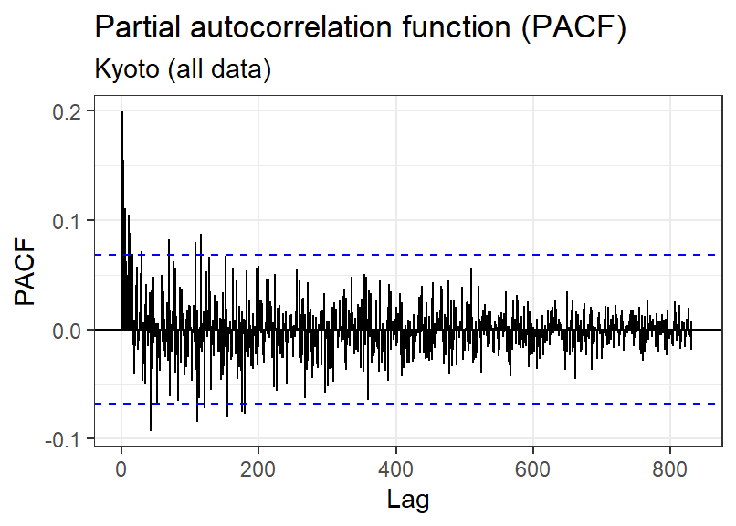

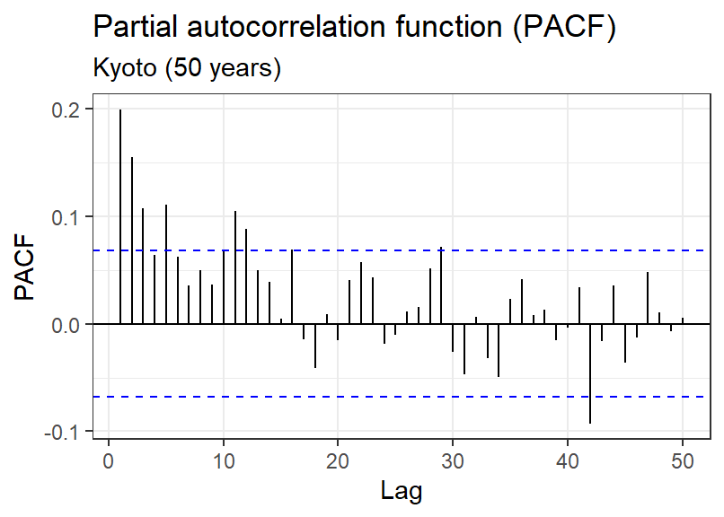

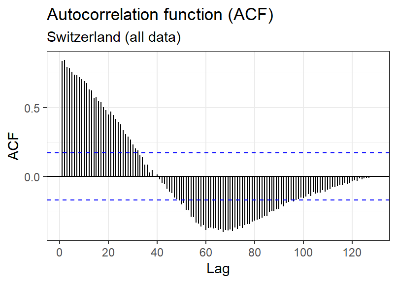

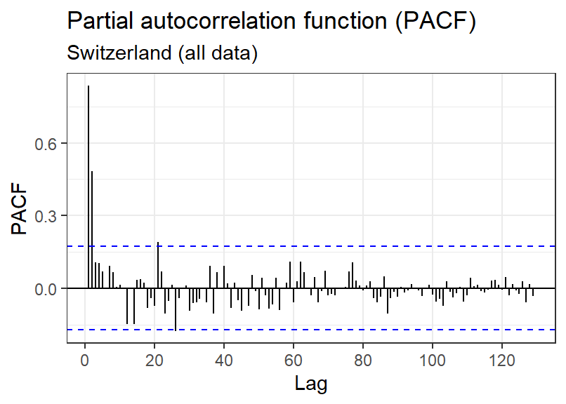

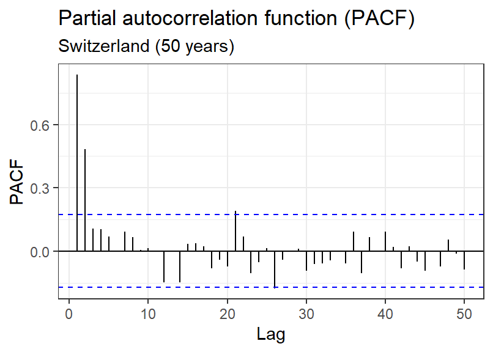

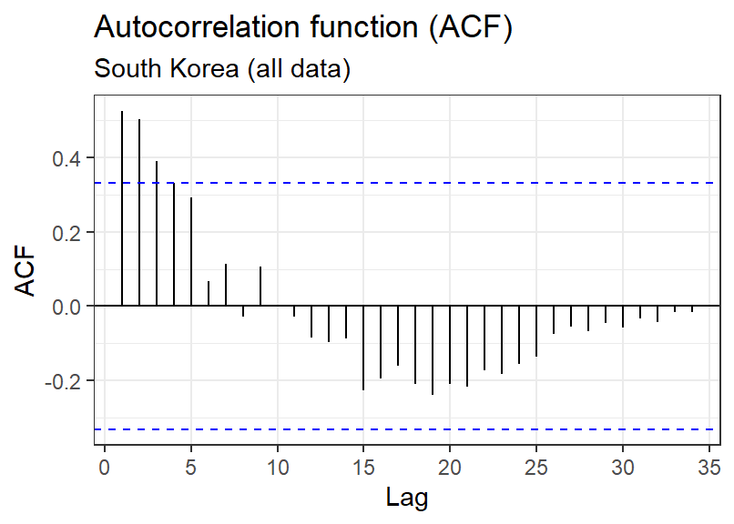

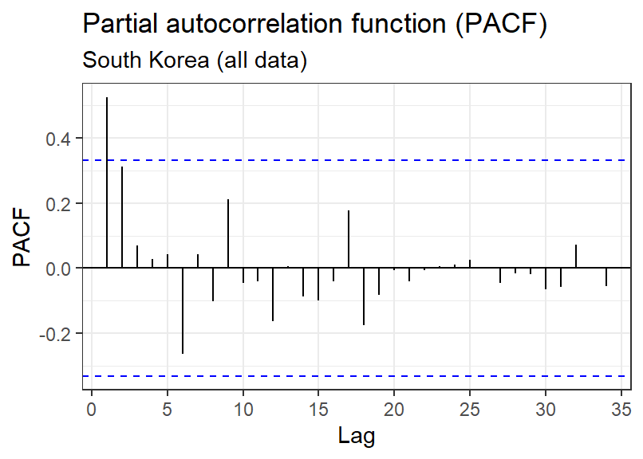

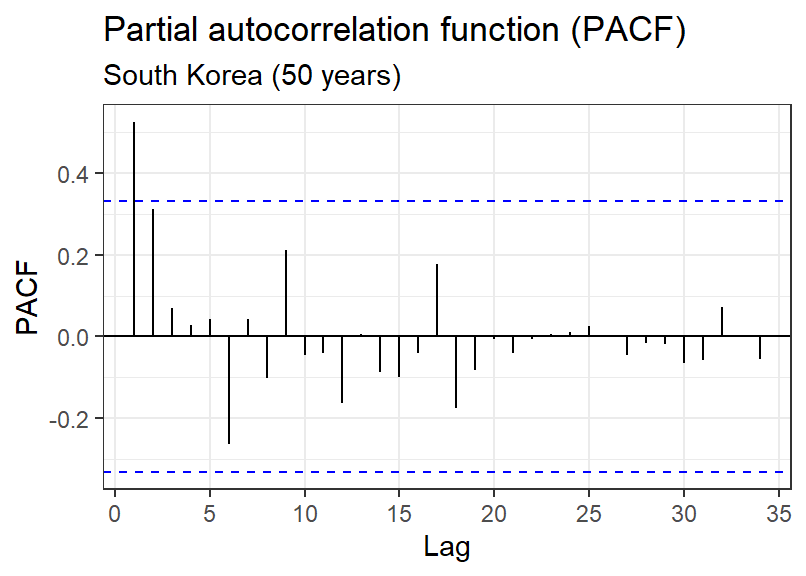

[3 more figures not shown]

```r
# Japan
plotACFMaxDOY(data = df_full, country_sel = countries[1])$plot1
plotACFMaxDOY(data = df_full, country_sel = countries[1])$plot2
plotACFMaxDOY(data = df_full, country_sel = countries[1])$plot3
# Tokyo
plotACFMaxDOY(data = df_full |> filter(str_detect(location, "kyoto|Kyoto|KYOTO")),
              country_sel = countries[1])$plot1 +
  labs(subtitle = "Kyoto (all data)")
plotACFMaxDOY(data = df_full |> filter(str_detect(location, "kyoto|Kyoto|KYOTO")),
              country_sel = countries[1])$plot2 +
  labs(subtitle = "Kyoto (all data)")
plotACFMaxDOY(data = df_full |> filter(str_detect(location, "kyoto|Kyoto|KYOTO")),
              country_sel = countries[1])$plot3 +
  labs(subtitle = "Kyoto (50 years)")
# Switzerland
plotACFMaxDOY(data = df_full, country_sel = countries[2])$plot1
plotACFMaxDOY(data = df_full, country_sel = countries[2])$plot2
plotACFMaxDOY(data = df_full, country_sel = countries[2])$plot3
# South Korea
plotACFMaxDOY(data = df_full, country_sel = countries[3])$plot1
plotACFMaxDOY(data = df_full, country_sel = countries[3])$plot2
plotACFMaxDOY(data = df_full, country_sel = countries[3])$plot3
# USA-WDC
plotACFMaxDOY(data = df_full, country_sel = countries[4])$plot1
plotACFMaxDOY(data = df_full, country_sel = countries[4])$plot2
plotACFMaxDOY(data = df_full, country_sel = countries[4])$plot3
```